# Estimation of Heterogeneous Treatment Effects and Treatment Policies

Prof. Susan Athey

Stanford University

PhD candidate, Vitor Hadad

Boston College and Stanford University

PhD student, Nicolaj Naargaard Mahlbach

Aarhus University

May, 2018

Abstract

In this tutorial, you will learn about machine learning methods for the estimation of heterogeneous treatment effects in randomized experiments and observational data. These include causal trees and forests and X-learners. Also, at the end, you will also be introduced to the problem of estimation of treatment policies.

Before beginning the tutorial, make sure that you have all the necessary packages. Try running the cell below and, if any issues arise, follow the instructions within.

```r
knitr::opts_chunk$set(echo=TRUE, warning=FALSE, message=FALSE, comment=NA)

# CRAN Packages
# -------------
# If any of these packages are not installed, write
# install.packages("<name of package>")
#install.packages("fBasics")

library(fBasics)     # Summary statistics
library(corrplot)    # Correlations
library(psych)       # Correlation p-values
library(glmnet)      # Linear models with L1 or L2 penalty
library(glmnetUtils) # Extra utilities for glmnet
library(grf)         # Generalized random forests
library(rpart)       # CART
library(rpart.plot)  # Plotting CART
library(treeClust)     # Predicting where leaf position

library(devtools)
library(tidyverse)    # Collection of great packages for modern R
library(knitr)        # RMarkdown
library(kableExtra)   # Prettier RMarkdown


# Non-CRAN Packages
# -----------------
# If any of these packages are not installed,
# uncomment the relevant line below
# Note: install_github is a function from the devtools package
#install_github('susanathey/causalTree')
library(causalTree)
#install_github('soerenkuenzel/hte')
library(hte)
```

# Introduction

One of machine learning’s great successes in the last decade is the production of quality predictive estimates using high-dimensional data. Because such predictions can be used to target small subpopulations with very specific characteristics, machine learning methods can be tremendously useful in many different fields ranging from personalized medicine to targeted advertising.

However, machine learning methods come with caveats. First, the researcher may end up finding *spurious* effects (i.e., by sheer chance some subpopulations might seem exhibit significant treatment effects that are not really there). Second, the optimization criteria used in off-the-shelf ML methods is often not appropriate for causal inference.

In this tutorial, you will learn about several new developments in the intersection of machine learning and econometrics that seek to ameliorate these issues.

## Conditional Average Treatment Effects

Let’s formalize the problem. We observe a sequence of triples $\{(W_i, Y_i, X_i)\}_{i}^{N}$, where $W_i$ represents whether subject $i$ was “treated”, $Y_i$ is a variable representing the outcome, and $X_i$ is a potentially very high-dimensional vector of other observable characteristics. We will be concerned with estimating the **conditional average treatment effect (CATE)** given each level $X_i =x$. We denote this by

$$\tau(x) = E[Y(1) - Y(0) \ | \ X = x]$$

where, in the potential-outcomes framework of Rubin (1974), $Y_i(1)$ represents the **potential outcome** of subject $i$ had they received the treatment, and $Y_i(0)$ the same potential outcome had they not. Keep in mind that both $Y_i(1)$ and $Y_i(0)$ are random variables, and we only observe the realization of one of these two for each individual in our dataset.

There are two common assumptions in this literature. The first one will be called here the **overlap assumption**. It is formally stated as follows.

$$\forall x \in \text{supp}(X), \qquad 0 < P(W = 1 \ | \ X = x) < 1$$

Effectively, this assumption guarantees that no subpopulation indexed by $X=x$ is entirely located in only one of control or treatment groups. It is necessary to ensure that we are able to compare individuals in control and treatment for every subpopulation.

The second assumption is invoked when working with observational data, and is known as **unconfoundedness**. It is formalized as a conditional independence assumption as follows.

$$Y_i(1), Y_i(0) \perp W_i \ | \ X_i$$

Unconfoundedness implies that the treatment is randomly assigned within each subpopulation indexed by $X_i = x$. Alternatively, it means that once we know all observable characteristics of individual $i$, then knowing about his or her treatment status gives us no extra information about their potential outcomes.

We won’t need unconfoundedness in the applications below, since our data comes from a randomized experiment. However, had it not been the case, unconfoundedness would have been a necessary condition.

## Data and economic setup

The economic context in which we will be working is inspired by Gerber, Green, and Larimer (2008)’s paper “Social Pressure and Voter Turnout: Evidence from a Large-Scale Field Experiment” ([see article](http://isps.yale.edu/sites/default/files/publication/2012/12/ISPS08-001.pdf)). This paper begins by noting that voter turnout is hard to explain via theories based on rational self-interest behavior, because the observable payoff to voting seems so small that voter turnout should be much smaller than what we see in reality. It could be the case, then, that voters receive some unobserved utility from voting – they have fulfilled their civic duty – or it could be that voters feel pressured by their peers to exercise their voting duty. The authors are interested in understanding the latter effect. They pose the question: to what extent do *social norms* cause voter turnout? In other words, we would like to quantify the effect of social pressure on voter participation.

The outcome dataset is publicly available [here](https://github.com/gsbDBI/ExperimentData/tree/master/Social). In this tutorial, we will use the following variables from it.

| Variable | Meaning |
| --- | --- |
| outcome_voted | Indicator variable where $= 1$ indicates voted in the August 2006 primary ($Y_i$) |
| treat_neighbors | Indicator variable where $= 1$ indicates treatment ($W_i$) |
| sex | Indicator variable where $= 1$ indicates male |
| yob | Year of birth |
| g2000 | Indicator variable where $= 1$ indicates voted in the 2000 general |
| g2002 | Indicator variable where $= 1$ indicates voted in the 2002 general |
| p2000 | Indicator variable where $= 1$ indicates voted in the 2000 primary |
| p2002 | Indicator variable where $= 1$ indicates voted in the 2002 primary |
| p2004 | Indicator variable where $= 1$ indicates voted in the 2004 primary |
| city | City index |
| hh_size | Household size |
| totalpopulation_estimate | Estimate of city population |
| percent_male | Percentage males in household |
| median_age | Median age in household |
| median_income | Median income in household |
| percent_62yearsandover | Percentage of subjects of age higher than 62 yo |
| percent_white | Percentage white in household |
| percent_black | Percentage black in household |
| percent_asian | Percentage asian in household |
| percent_hispanicorlatino | Percentage hispanic or latino in household |
| employ_20to64 | Percentage of employed subjects of age 20 to 64 yo |
| highschool | Percentage having only high school degree |
| bach_orhigher | Percentage having bachelor degree or higher |

Below, we load the data as a .csv file, rename the response and the treatment variable to $Y$ and $W$, respectively, and extract the relevant covariates outlined above. Then, we standardize the continuous covariates to have zero mean and unit variance and omit observations with *NA* entries.

```r
# Clear any existing variables
rm(list = ls())

# Set seed for reproducibility
set.seed(109)

# Load data
data_raw <- read_csv('socialneighbor.csv')

# These are the covariates we'll use
cts_variables_names <- c("yob", "city", "hh_size", "totalpopulation_estimate",
                         "percent_male", "median_age",
                         "percent_62yearsandover",
                         "percent_white", "percent_black",
                         "percent_asian", "median_income",
                         "employ_20to64", "highschool", "bach_orhigher",
                         "percent_hispanicorlatino")
binary_variables_names <- c("sex","g2000", "g2002", "p2000", "p2002", "p2004")
covariates <- c(cts_variables_names, binary_variables_names)
all_variables_names <- c(covariates, "outcome_voted", "treat_neighbors")

# We will not use all observations -- it would take too long to run all the methods below
n_obs <- 32000

# Selecting only desired covariates
df <- data_raw %>%
  dplyr::sample_n(n_obs) %>%
  dplyr::select(all_variables_names)
```

## Descriptive statistics

Let’s begin by showing some basic summary statistics. The function `fBasics::basicStats` does most of the job for us, and HTML output is handled by `knitr::kable` and `kableExtra::kable_styling`.

|  | Mean | Stdev | Minimum | Lower quartile | Median | Upper quartile | Maximum |
| --- | --- | --- | --- | --- | --- | --- | --- |
| yob | 1954.71 | 14.25 | 1900.0 | 1946.0 | 1955.0 | 1964.0 | 1986.0 |
| city | 13.85 | 24.95 | 0.0 | 1.0 | 2.0 | 12.0 | 100.0 |
| hh_size | 1.92 | 0.72 | 1.0 | 1.0 | 2.0 | 2.0 | 7.0 |
| totalpopulation_estimate | 20661.84 | 12918.76 | 554.0 | 9205.0 | 19822.0 | 30448.0 | 63332.0 |
| percent_male | 49.42 | 1.96 | 40.9 | 48.3 | 49.2 | 50.4 | 76.7 |
| median_age | 39.90 | 4.46 | 21.4 | 37.4 | 40.0 | 42.4 | 60.8 |
| percent_62yearsandover | 17.10 | 4.46 | 4.4 | 14.2 | 16.6 | 19.3 | 46.7 |
| percent_white | 92.47 | 8.09 | 36.0 | 89.1 | 95.7 | 97.8 | 100.0 |
| percent_black | 4.32 | 6.20 | 0.0 | 0.9 | 2.2 | 5.2 | 64.2 |
| percent_asian | 2.60 | 3.80 | 0.0 | 0.6 | 1.4 | 2.8 | 27.9 |
| median_income | 59901.33 | 18233.85 | 26155.0 | 47000.0 | 55936.0 | 69201.0 | 138884.0 |
| employ_20to64 | 71.35 | 6.16 | 19.7 | 68.1 | 72.5 | 75.4 | 86.3 |
| highschool | 29.82 | 8.95 | 6.2 | 24.4 | 30.1 | 36.7 | 55.1 |
| bach_orhigher | 28.96 | 14.41 | 2.3 | 17.6 | 27.2 | 36.2 | 77.0 |
| percent_hispanicorlatino | 3.79 | 4.04 | 0.0 | 1.7 | 2.6 | 4.1 | 37.6 |
| sex | 0.51 | 0.50 | 0.0 | 0.0 | 1.0 | 1.0 | 1.0 |
| g2000 | 0.86 | 0.34 | 0.0 | 1.0 | 1.0 | 1.0 | 1.0 |
| g2002 | 0.83 | 0.37 | 0.0 | 1.0 | 1.0 | 1.0 | 1.0 |
| p2000 | 0.27 | 0.44 | 0.0 | 0.0 | 0.0 | 1.0 | 1.0 |
| p2002 | 0.41 | 0.49 | 0.0 | 0.0 | 0.0 | 1.0 | 1.0 |
| p2004 | 0.42 | 0.49 | 0.0 | 0.0 | 0.0 | 1.0 | 1.0 |
| outcome_voted | 0.32 | 0.47 | 0.0 | 0.0 | 0.0 | 1.0 | 1.0 |
| treat_neighbors | 0.17 | 0.37 | 0.0 | 0.0 | 0.0 | 0.0 | 1.0 |

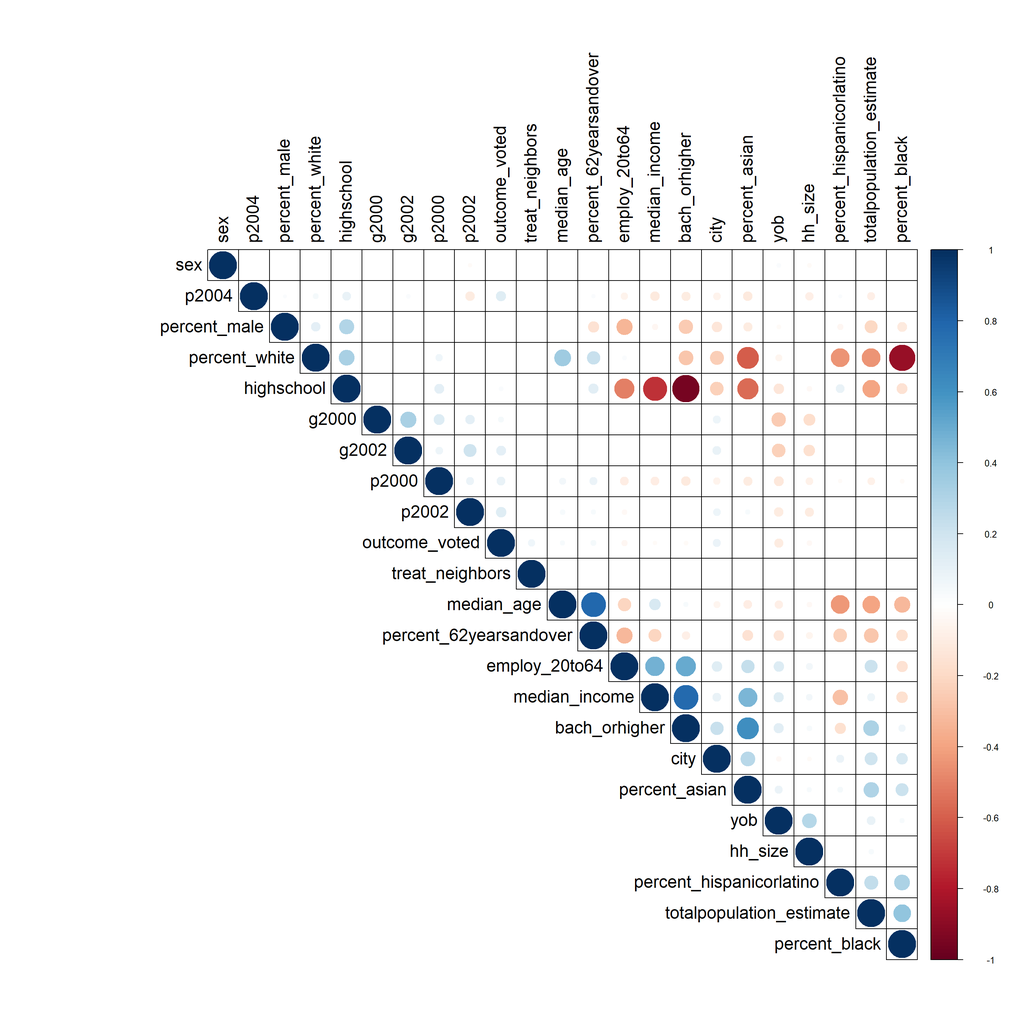

## Preparing the data

It’s often advantageous to scale regressors to zero mean and unit variance. In fact, many of the R packages we will use below will do it automatically, but we will go ahead and show how to do it manually in the next snippet.

```r
# Extracting and scaling continuous variables
scaled_cts_covariates <- df %>%
  dplyr::select(cts_variables_names) %>%
  dplyr::mutate_all(scale)

# Extracting indicator variables
binary_covariates <- df %>%
  dplyr::select(binary_variables_names)

# Extracting outcome and treatment
outcome <- df %>% dplyr::select(outcome_voted)
treatment <- df %>% dplyr::select(treat_neighbors)

# Setting up the data, renaming columns and discarding rows with NA (if any)
df <- bind_cols(scaled_cts_covariates, binary_covariates, outcome, treatment) %>%
  plyr::rename(c(treat_neighbors = "W",
                 outcome_voted = "Y")) %>%
  na.omit()
```

Next, let’s divide our data set into a training set and a test set. The function resample_partition, part of the modelr package will do that for us automatically.

This dataset is large, so we are using a large test set. If we had a smaller dataset we might use a similar size training set and a smaller test set.

```r
set.seed(1234)
df_part <- modelr::resample_partition(df, c(train = 0.5, test = 0.5))
df_train <- as.data.frame(df_part$train)
df_test <- as.data.frame(df_part$test)
```

# Recursive Partitioning

Before conducting drug trials, researchers must often pre-register their analysis in order to prevent ex-post data-mining (i.e., cherry-picking patients for which drug worked based on spurious results). At the same time, there is a desire to know for which subpopulations the drug has strongest or weakest effects. In such cases, having a data-driven way to find out where is the relevant heterogeneity that still produces usable estimates can be very convenient.

This was one of the motivations for Athey and Imbens (2016)’s **causal trees**, a method for estimating heterogeneity in causal effects in experimental and observational studies, and for conducting hypothesis tests about the magnitude of the differences in treatment effects across subsets of the population.

Their main idea is to use a portion of the data to understand where the treatment heterogeneity is, and find an according partition of the covariate space (e.g, “*men* over/under the age of *50*”), while using the rest of the data to answer what is the treatment effect on each portion of this partition. They also prove that this allows them to produce unbiased and asymptotically Normal estimates of the treatment effect for each subgroup.

```r
# Split training data further into tree training and estimation samples
df_split <- modelr::resample_partition(df_train, c(train=0.5, estim=0.5))
df_tr <- as_tibble(df_split$train)
df_est <- as_tibble(df_split$estim)

set.seed(1003)
tree <- causalTree::honest.causalTree("I(factor(Y)) ~ . -W",
                  data=df_tr,
                  treatment=df_tr$W,
                  est_data=df_est,
                  est_treatment=df_est$W,
                  split.Rule="CT",
                  split.Honest=TRUE,
                  split.Bucket=TRUE,
                  bucketNum=5,
                  bucketMax=100,
                  cv.option="CT",
                  cv.Honest=TRUE,
                  minsize=200,
                  split.alpha=0.5,
                  cv.alpha=0.5,
                  HonestSampleSize=length(df_split$estim$idx),
                  cp=0)

opcp <- tree$cptable[,1][which.min(tree$cptable[,4])]
opfit <- prune(tree, opcp)
tauhatx_ct <- predict(opfit, df_test)
```

# Causal Forests

When the researcher has reasons to believe that the treatment effect heterogeneity is not sparse or very high dimensional, semi- and non-parametric methods based on nearest-neighbor matching, kernels or series expansions might be more appropriate. The problem with these methods is that tend to suffer acutely from the **curse of dimensionality**, so in high-dimensional or very nonlinear scenarios, practitioners may prefer to use an ensemble method like **random forests** instead. Causal forests present one solution in this setting.

```r
# Fit the model
set.seed(1001)

# Note: If these commands fail, please upgrade to grf version 0.10.0 and restart R

# Estimate the outcome model (ignoring treatment)
y.forest = grf::regression_forest(as.matrix(df_train[covariates]), df_train$Y,
                                  tune.parameters = TRUE)
Y.hat = predict(y.forest)$predictions

# Because we're in an RCT, estimate the propensity score as constant
W.hat = rep(mean(df_train$W), length(df_train$W))

#w.forest = grf::regression_forest(as.matrix(df_train[covariates]), as.matrix(df_train["W"]),
#                                  tune.parameters = TRUE)
#W.hat = predict(w.forest)$predictions

# To speed things up in testing, do not tune.parameters, but should tune in final runs
cf <- grf::causal_forest(X = as.matrix(df_train[covariates]),
                         Y = df_train$Y,
                         W = df_train$W,
                         W.hat = W.hat, Y.hat = Y.hat,
                         tune.parameters = TRUE)

# Predict CATE and its std error for each individual on the dataset
cf_res <- predict(cf, df_test[covariates])
tauhatx_cf <- cf_res$predictions %>% as.numeric()
```

# X-learners

Kunzel et al (2017) propose a new meta-algorithm for CATE estimation. The authors begin by noting that many CATE algorithms either separately estimate *two* response functions, as in:

$$\mu_1(x) = E[Y(1) | X=x] \qquad \text{and} \qquad \mu_1(x) = E[Y(0)|X=x]$$

or they put the treatment variable along with the control variables and estimate a *single* function, like so:

$$\mu(w, x) = E[Y(1) | W = w, X=x]$$

They call the former class of methods *T-learners* (for “two”) and the latter one *S-learners* (for “single”). Then, they propose an alternative *X-learner* that has the following procedure.

1. Use any method to estimate separate response functions $\mu_1(x)$ and $\mu_0(x)$.
2. Create *imputed individual treatment effects*:
   $$\begin{align}
   &\hat{D}_{1_i} = Y_i - \mu_0(X_i) \qquad \forall i \text{ in control group} \\
   &\hat{D}_{0_i} = Y_i - \mu_1(X_i) \qquad \forall i \text{ in treatment group}
   \end{align}$$
3. Regress imputed treatment effects on covariates to obtain CATE estimates $\hat{\tau}_{0}(x)$ and $\hat{\tau}_1(x)$
4. Take a weighted average of the CATE estimates
   $$\hat{\tau}(x) = \hat{g}(x)\hat{\tau}_0(x) + [1-\hat{g}(x)]\hat{\tau}_1(x)$$
   where $g$ is a function mapping to unit interval, typically chosen to be the propensity score.

The motivation for this procedure is this. An *S-learner* works well when one of the treatment groups is much larger than the other because it pools information about both groups and so is able to pick up common trends in the data. On the other hand, the same *S-learner* might choose to completely ignore information about the treatment (e.g. a tree that doesn’t split on $W_i$), which ends up biasing the CATE to zero since the resulting estimated function will be constant in $w$. In this case, a *T-learner* would do better. The authors claim that their meta-algorithm is able to ameliorate both of these disadvantages by the “crossing” technique (hence *“X”-learner*) shown in step 2 above.

The snippet below uses code from the hte package developed by K"{u}nzel et al (2017). Here we have chosen random forests as our base learner, but the package also contains a BART implementation.

```r
xl <- hte::X_RF(feat = as.data.frame(df_train[covariates]),
                 tr = df_train$W,
                 yobs = df_train$Y,
                 ntree_first = 500,
                 ntree_second = 500,
                 ntree_prop = 500,
                 nthread = 1)

tauhatx_xl <- hte::EstimateCate(xl, df_test[covariates])
```

# Visualizing and interpreting results

Note: the code used in this section consists mostly of plot tuning that is not very interesting for us.  
In order to reduce the clutter, we will hide the code, but you can still check it out in the original `.Rmd` source.

## Visualizing heterogeneity

For tree-based methods that output `rpart`-like objects, we can use the library `rpart.plot` to visualize the estimated tree. Here’s what the output of our causal trees looks like. NOTE: We plot both the pruned and unpruned here because the pruned tree does not split much or at all with a small dataset. In practice “opfit”, the pruned tree, should be used.

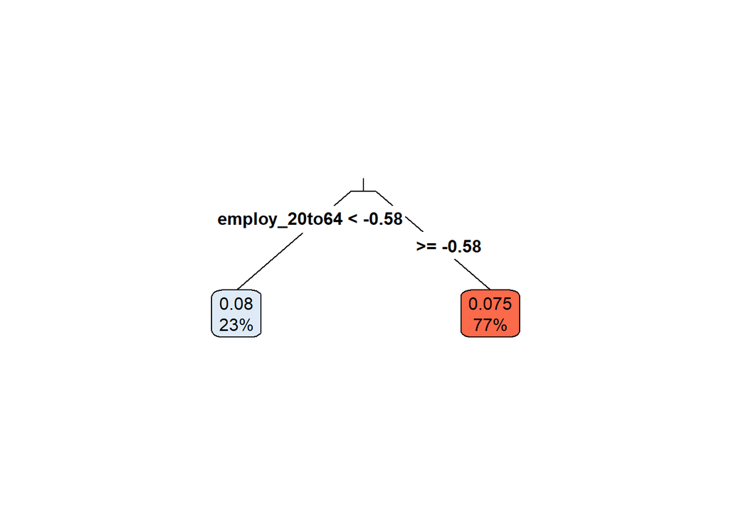

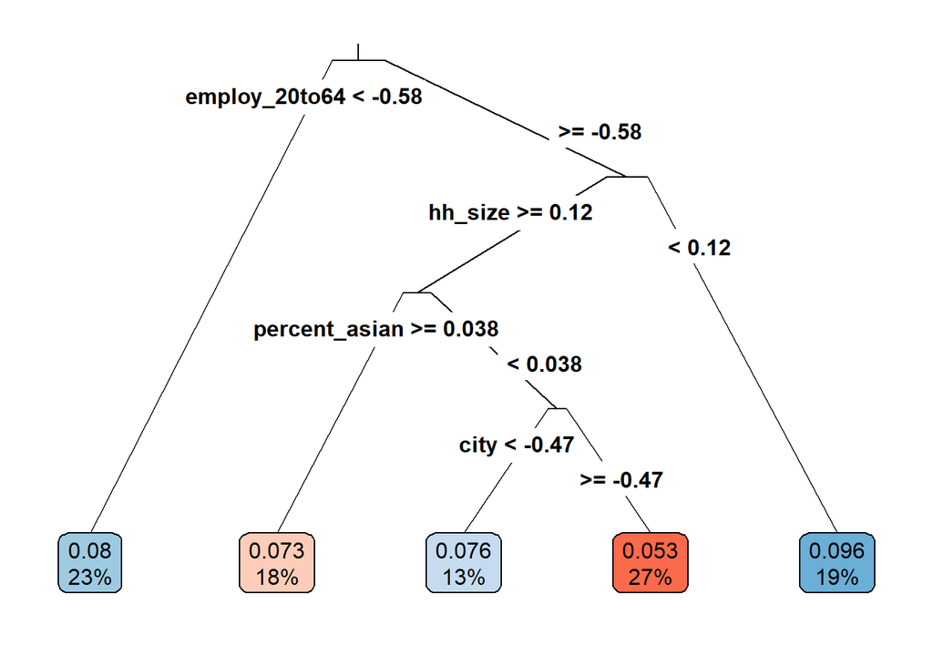

To get the treatment effects and standard errors, there are several approaches, but the following is an easy approach.

```r
df_tr$leaf <- as.factor(round(predict(tree,
                                       newdata = df_tr,
                                       type = "vector"), 4))

df_est$leaf <- as.factor(round(predict(tree,
                                       newdata = df_est,
                                       type = "vector"), 4))

df_test$leaf <- as.factor(round(predict(tree,
                                       newdata = df_test,
                                       type = "vector"), 4))

# Run linear regression that estimate the treatment effect magnitudes and standard errors
ols_leaves_tr <- lm( Y ~ leaf + W * leaf - W -1, data = df_tr)
ols_leaves_est <- lm( Y ~ leaf + W * leaf - W -1, data = df_est)
ols_leaves_test <- lm( Y ~ leaf + W * leaf - W -1, data = df_test)

summary(ols_leaves_tr)
```

```
Call:
lm(formula = Y ~ leaf + W * leaf - W - 1, data = df_tr)

Residuals:
    Min      1Q  Median      3Q     Max
-0.4833 -0.3091 -0.2888  0.6537  0.7945

Coefficients:
             Estimate Std. Error t value Pr(>|t|)
leaf0.0526    0.30658    0.01091  28.105  < 2e-16 ***
leaf0.0734    0.28883    0.01339  21.574  < 2e-16 ***
leaf0.0765    0.20550    0.01597  12.868  < 2e-16 ***
leaf0.08      0.34628    0.01166  29.706  < 2e-16 ***
leaf0.0958    0.30910    0.01278  24.187  < 2e-16 ***
leaf0.0526:W  0.17671    0.02771   6.377 1.91e-10 ***
leaf0.0734:W  0.06156    0.03193   1.928  0.05391 .
leaf0.0765:W  0.10418    0.04040   2.579  0.00994 **
leaf0.08:W    0.03292    0.02919   1.128  0.25951
leaf0.0958:W  0.12816    0.03122   4.104 4.10e-05 ***
---
Signif. codes:  0 '***' 0.001 '**' 0.01 '*' 0.05 '.' 0.1 ' ' 1

Residual standard error: 0.462 on 7989 degrees of freedom
Multiple R-squared:  0.3281,    Adjusted R-squared:  0.3272
F-statistic:   390 on 10 and 7989 DF,  p-value: < 2.2e-16
```

```r
summary(ols_leaves_est)
```

```
Call:
lm(formula = Y ~ leaf + W * leaf - W - 1, data = df_est)

Residuals:
    Min      1Q  Median      3Q     Max
-0.4107 -0.3306 -0.2968  0.6691  0.8067

Coefficients:
             Estimate Std. Error t value Pr(>|t|)
leaf0.0526    0.33087    0.01103  29.988  < 2e-16 ***
leaf0.0734    0.29684    0.01317  22.544  < 2e-16 ***
leaf0.0765    0.19325    0.01578  12.250  < 2e-16 ***
leaf0.08      0.33056    0.01170  28.247  < 2e-16 ***
leaf0.0958    0.31484    0.01292  24.363  < 2e-16 ***
leaf0.0526:W  0.05255    0.02599   2.022  0.04321 *
leaf0.0734:W  0.07336    0.03466   2.117  0.03432 *
leaf0.0765:W  0.07649    0.04068   1.880  0.06014 .
leaf0.08:W    0.08004    0.02907   2.754  0.00590 **
leaf0.0958:W  0.09580    0.03130   3.061  0.00222 **
---
Signif. codes:  0 '***' 0.001 '**' 0.01 '*' 0.05 '.' 0.1 ' ' 1

Residual standard error: 0.4624 on 7990 degrees of freedom
Multiple R-squared:  0.3249,    Adjusted R-squared:  0.324
F-statistic: 384.5 on 10 and 7990 DF,  p-value: < 2.2e-16
```

```r
summary(ols_leaves_test)
```

```
Call:
lm(formula = Y ~ leaf + W * leaf - W - 1, data = df_test)

Residuals:
    Min      1Q  Median      3Q     Max
-0.4571 -0.3285 -0.2825  0.6512  0.7986

Coefficients:
             Estimate Std. Error t value Pr(>|t|)
leaf0.0526   0.319436   0.007846  40.712  < 2e-16 ***
leaf0.0734   0.282481   0.009473  29.820  < 2e-16 ***
leaf0.0765   0.201405   0.011196  17.988  < 2e-16 ***
leaf0.08     0.348845   0.008347  41.792  < 2e-16 ***
leaf0.0958   0.328478   0.009059  36.259  < 2e-16 ***
leaf0.0526:W 0.071675   0.019462   3.683 0.000231 ***
leaf0.0734:W 0.062281   0.022306   2.792 0.005244 **
leaf0.0765:W 0.039283   0.027182   1.445 0.148433
leaf0.08:W   0.057111   0.020132   2.837 0.004561 **
leaf0.0958:W 0.128665   0.021550   5.970 2.42e-09 ***
---
Signif. codes:  0 '***' 0.001 '**' 0.01 '*' 0.05 '.' 0.1 ' ' 1

Residual standard error: 0.4627 on 15991 degrees of freedom
Multiple R-squared:  0.3289,    Adjusted R-squared:  0.3285
F-statistic: 783.7 on 10 and 15991 DF,  p-value: < 2.2e-16
```

In the OLS regressions, the coefficients of interest are the coefficients on the interaction between the leaf dummies and the treatment. These are exactly equal to the treatment effect in the leaf for that dataset. Note that the leaves are named according to the treatment effect from the honest causal tree, so the leaf names should be identical to the interaction coefficients for the estimation sample. We can compare those estimates to those in the training sample and in the test sample. The training sample was used to build the trees, and so is prone to overfitting; this shows up in effects that are more extreme than those found in the estimation and test sets.

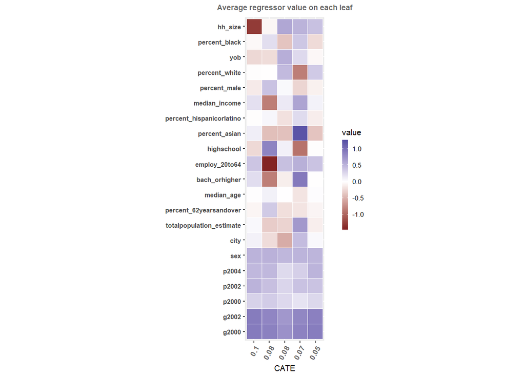

For more complex algorithms like causal forests, we can follow a similar approach by manually creating subpopulations based on predicted treatment effect strength. For variety, let’s show the output on barcharts this time.

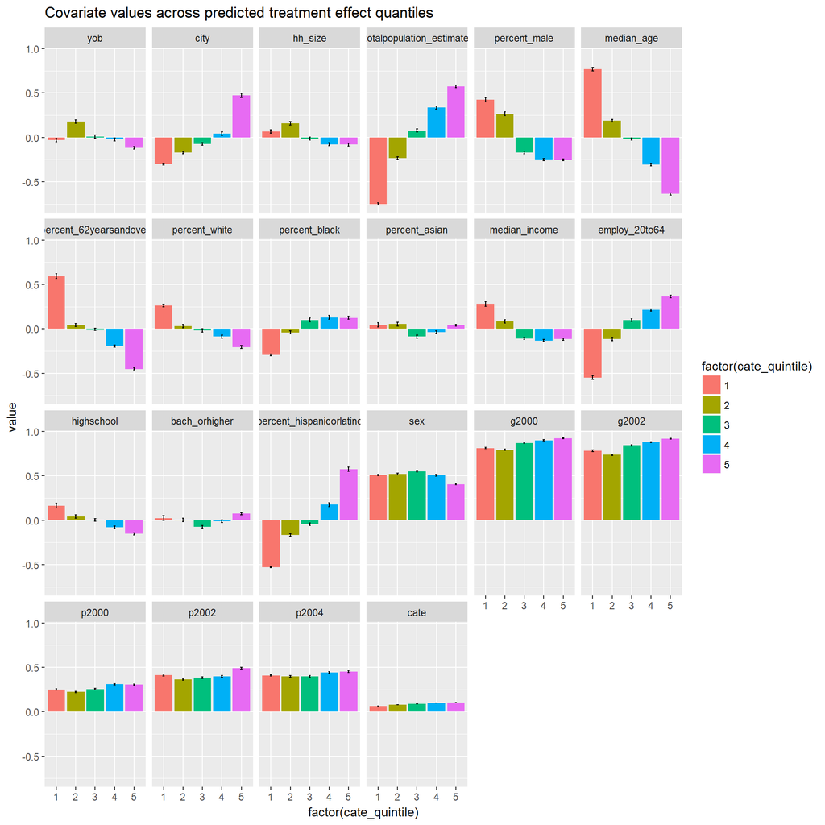

Once again, the group with largest effect (on the rightmost columns) seems to be composed of younger minority individuals living in more populated cities, whereas the average individual in the least affected group is more likely a white rural dweller. It’s also interesting to check out what the algorithm is detects no heterogeneity, like gender in this example.

**Remark** A caveat to the last few paragraphs is that we have been loosely describing the characteristics of each group without any explicit mention to statistical significance. While we won’t delve into that here, the researcher should take into account loss of power due multiple hypothesis testing, as recommended List, Shaikh and Xu (2016).

## Visualizing the effect of each covariate

A benefit of estimating CATE flexibly is that we can investigate what happens at specific points in the covariate space, thus producing a “personalized” estimate. In the panels below, we again divide the data set by causal forest-predicted quintiles, and check out how our estimates of the treatment effect change as we vary the variable `median_age`, keeping every other covariate at their quintile-group median.

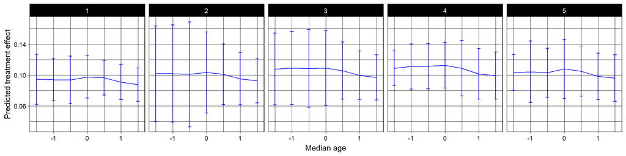

Confidence intervals will be large whenever there are few observations in the around the point we are estimating. (Note: we are only using a small portion of the original dataset in this tutorial. You may want to check out how these confidence intervals shrink by rerunning the code using the full dataset).

We can also do the same for two variables using a heatmap or a surface plot. Here’s an example.

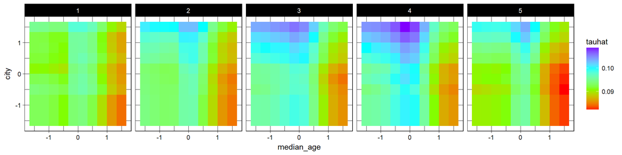

As we have seen before, young city dwellers seem to respond more strongly to the treatment than older rural dwellers.

# Comparing our predictions

We’d like to compare how well our methods performed in terms of prediction error. In order to do so, let’s begin by defining the following object.

$$\begin{align}
Y_i^{*} =
\begin{cases}
\frac{1}{p}Y_i \qquad &\text{if} \qquad W_i = 1 \\
\frac{-1}{1-p}Y_i \qquad &\text{if} \qquad W_i = 0
\end{cases}
\end{align}$$

where $p = P(W = 1)$. This is actually a high-variance unbiased estimator of the true individual treatment effect:

$$\begin{align}
E[Y_i^{*}] &= P(W=1)E[Y_i^{*}|W=1] + P(W=0)E[Y_i^{*}|W=0] \\
&= pE[\frac{1}{p}Y_i|W=1] + (1-p)E[\frac{-1}{1-p}Y_i|W=0] \\
&= pE[\frac{1}{p}Y_i(1)] + (1-p)E[\frac{-1}{1-p}Y_i(0)] \\
&= E[Y_i(1) - Y_i(0)] \\
&= E[\tau_i]
\end{align}$$

**Note** The third equality worked here because we are using a randomized experiment, but it would have worked us as well in a scenario with unconfoundedness provided that we used the propensity score $p(x) = P(W = 1 | X= x)$ instead of $p$.

In expectation, the squared distance between $Y_i^*$ and our prediction $\hat\tau(X_i)$ can be used to compare our estimators’ mean square error. This is because of the following.

$$\begin{align}
E[(Y_i^{*} - \hat{\tau}(X_i))^2]
&= E[(Y_i^{*} - \tau_i + \tau_i - \hat{\tau}(X_i))^2] \\
&= E[(Y_i^{*} - \tau_i)^2] + E[(\tau_i - \hat{\tau}(X_i))^2]
+ 2E[(Y_i^{*} - \tau_i)(\tau_i - \hat{\tau}(X_i))]\\
&= const + E[(\tau_i - \hat{\tau}(X_i))^2] + 0
\end{align}$$

where the first term in the last equality is a constant with respect to the algorithm used, so it gets cancelled out when we take the difference between two estimators.

```r
p <- mean(df_test$W)

ystar <- (df_test$W - p)/(p*(1-p))*df_test$Y

MSE <- as_tibble(list(
            causal_trees = (ystar - tauhatx_ct)^2,
            causal_forests = (ystar - tauhatx_cf)^2,
            xlearners = (ystar - tauhatx_xl)^2))


m <- MSE %>% summarize_all(mean)
s <- MSE %>% map_df(~sqrt(var(.)/length(.)))
MSE_table <- bind_rows(m ,s)
rownames(MSE_table) <- c("mean", "stderr")
kable(MSE_table,  booktabs = T, digits = 3)
```

|  | causal_trees | causal_forests | xlearners |
| --- | --- | --- | --- |
| mean | 2.578 | 2.578 | 2.578 |
| stderr | 0.064 | 0.064 | 0.064 |

**Caveat** A flexible model like causal forests, while in theory being able to produce asymptotically unbiased and Normal estimates, in practice will only be able to do so if we have a sufficient number of observations. We haven’t really escaped the curse of dimensionality, so if the heterogeneity we are trying to model is very high-dimensional and highly nonlinear with multiple interactions, we won’t be able to produce reliable personalized estimates unless we have extremely large amounts of data. On the other hand, a simpler model like causal trees “moves the goalpost”: it forgoes personalized estimates and fits a smaller number of parameters, but produces valid, high-quality estimates for specific subgroups. Practitioners should always keep these trade-offs in mind, decide what type of question they can answer, and choose their algorithms accordingly.

# Estimation of treatment policies

The reason we care about treatment effect heterogeneity is that we’d like to assign the correct treatment to each individual or subpopulation. For example, a costly get-out-the-vote campaign should send mailings only to those more susceptible to it. Similarly, in the context of personalized medicine, a doctor would like to know whether to prescribe a treatment only if she expects it to improve her patient’s condition. Or yet, in the advertising business, a company could save a lot of money by targeting users who are likely to purchase their product.

To put it mathematically, we’d like to select a function $\pi$ that maps observed characteristics to an available action. Such a function is called a **policy**, and, in our context of treatment assignment, it maps an individual’s characteristics to their level of treatment:

$$\pi : X_i \mapsto W_i$$

An optimal treatment assignment policy is one that maximizes expected utility.

$$\pi^{*} \in \arg\max_{\pi \in \Pi} E[Y_i(\pi(X_i))] \qquad \text{ where } \Pi \text{ is a set of candidate policies }$$

Any other non-optimal policy experiences **regret** $R(\pi)$.

$$R(\pi) = E[Y_i(\pi^{*}(X_i))] - E[Y_i(\pi(X_i))]$$

In Athey and Wager (2017), the authors study the problem of learning, from observational data, a binary treatment assignment policy $\hat{\pi}: X_i \mapsto \{+1,-1\}$ (the sign indicates treatment or not treatment). They show that, under unconfoundedness and the overlap assumption, it is possible to learn a function that exhibits small regret, and whose complexity increases with the amount of data.

Before delving into the finer details, here’s the intution. Suppose that we had access to an estimate of the treatment effect $\hat{\Gamma}_i$ for each individual $i$. Whenever $\hat{\Gamma}_i$ is positive, we’d like our policy to assign this individual to treatment ($\pi(X_i) = 1$), and not assign them when it’s negative ($\pi(X_i) = -1$). In other words, we would like to maximize the average of the product $\pi(X_i)\Gamma_i$ across individuals:

$$\hat{Q}(\pi) = \frac{1}{n}\sum_i \pi(X_i) \hat{\Gamma}_i$$

Next, we can transform this into a problem that we are used to solving. By breaking down $\hat{\Gamma}_i = |\hat{\Gamma}_i| \cdot \text{sign}(\hat{\Gamma}_i)$ we can recast this as a classification problem where the goal is try to maximize the correlation between the policy assignment ($\pi(X_i) \in \{ +1, -1\}$) and the sign of its estimated effect ($sign(\hat{\Gamma}_i) \in \{ +1, -1\}$). Also, note the role of the weights: if a patient had $\hat{\Gamma} \gg 0$ but our policy predicted $\hat{\pi}(X_i) = -1$, it would have pay the very large penalty of $-\hat{\Gamma}_i$. An optimal policy will be the function that is able avoid this mistake the most within the available class $\Pi$.

Before we move on, let’s just take a moment to note that while we have rewritten this as a classification problem for algorithmic purposes, our objective is actually not to estimate a propensity score. We are not trying to predict the treatment of past individuals – in fact, this method can be used even if the treatment was randomly assigned! Instead, we are fitting a new function that will allow us to *choose* a treatment assignment status given individual characteristics. In other words, we are producing a rule that answers the question: “if a new individual $j$ with characteristics $X_j$ comes tomorrow, should we send them to treatment or not?” And if patient $j$ has similar characteristics to patients with high $\hat{\Gamma}_i$ in the data, then $j$ should be “classified” into treatment.

Back to the problem at hand. So far, we have been assuming access to good estimates of the treatment effect $\hat{\Gamma}_i$. What makes Athey and Wager (2017)’s method powerful is that they indeed provide us with provably optimal estimates of it (in the sense of semiparametric efficiency). This is possible by leveraging ideas from the doubly-robust estimation literature, in particular using the **double machine learning** methods of Chernozhukov et al (2017).

$$\hat{\Gamma}_i := \hat{\mu}_{+1}^{-k(i)}(X_i) - \hat{\mu}_{-1}^{-k(i)}(X_i) + W_i \frac{Y_i - \hat{\mu}_{W_i}^{-k(i)}(X_i)}{\hat{e}_{W_i}^{-k(i)}(X_i)}$$

Forgetting about the superscripts for a moment, this should look familiar: the first two terms make up a direct estimates of CATE, where the last term is an inverse propensity score estimate of the same object. This is a *doubly-robust* estimator because only one of $\hat{\mu}$ or $\hat{e}$ needs to be correctly specified, and the term *double machine learning* is used because they can be semi- or non-parametric estimators from the machine learning literature. Finally, the superscripts indicate a form of sample splitting: the data is divided into $K$ evenly-sized folds, and the prediction for the $i$th individual from fold $k(i)$ uses function that were estimated on the remaining folds.

In the snippet below, we apply Athey and Wager (2017)’s method to our data. Note again that we are working on experimental data in this tutorial, but everything would work on observational data as well under unconfoundedness.

First we will estimate $\Gamma_i$. To make things simple and fast, we will re-use estimates from the causal forest. To make this interesting, assume that there is a COST of 0.1 to treating an individual (so the policy isn’t just to send everyone to treatment–in another dataset, you could set this equal to the mean treatment effect).

In the code, note here that relative to the notes and paper, our W is in {0,1} rather than {-1,1}.

We also look at two alternative methods, one where we use a tree-based policy, but base the assignments on the estimated $\hat\tau(X_i)$; and another where we do not assume a simple tree-based policy, and assign the treatment to all people with positive values of $\hat\tau(X_i)-COST$.

```r
tau.hat = predict(cf, data=df_train)$predictions
df_train$tau.hat <- as.numeric(tau.hat)
df_train$W.hat <- as.numeric(W.hat)

#Estimate predictive models separately for the treatment and control groups
df_train_treat <- df_train[df_train$W==1,]
y1.forest = grf::regression_forest(as.matrix(df_train_treat[covariates]), df_train_treat$Y,
                                  tune.parameters = TRUE)
df_train$Y1.hat = predict(y1.forest, newdata=df_train)$predictions

df_train_control <- df_train[df_train$W==0,]
y0.forest = grf::regression_forest(as.matrix(df_train_control[covariates]), df_train_control$Y,
                                  tune.parameters = TRUE)
df_train$Y0.hat = predict(y0.forest, newdata=df_train)$predictions

#Impose a cost to make the problem interesting--this would be different in each application, somewhere around the mean treatment effect
COST = 0.1

#Gamma from the notes
df_train$gamma = tau.hat- COST + df_train$W*(df_train$Y - df_train$Y1.hat) / df_train$W.hat - (1 - df_train$W)* (df_train$Y - df_train$Y0.hat)/ (1 - df_train$W.hat)

#alternative Gamma based on just tau.hat
df_train$gamma2 = tau.hat - COST
summary(df_train$tau.hat)
```

```
   Min. 1st Qu.  Median    Mean 3rd Qu.    Max.
0.01385 0.07819 0.08994 0.08720 0.09824 0.12722
```

```r
summary(df_train$gamma)
```

```
       V1
 Min.   :-3.34626
 1st Qu.:-0.73689
 Median : 0.24347
 Mean   :-0.01335
 3rd Qu.: 0.34365
 Max.   : 4.84809
```

```r
summary(df_train$gamma2)
```

```
       V1
 Min.   :-0.086149
 1st Qu.:-0.021813
 Median :-0.010055
 Mean   :-0.012795
 3rd Qu.:-0.001761
 Max.   : 0.027223
```

```r
# Create augmented data set with Z and lambda
df_aug <- df_train %>%
            mutate(Z = sign(gamma)) %>%  # Is the effect positive?
            mutate(lambda = abs(gamma))  # How large is it?
df_aug$Z2 <- sign(df_aug$gamma2)
df_aug$lambda2 <- abs(df_aug$gamma2)

df_aug$Z <- factor(df_aug$Z, labels = c("Don't", "Treat"))
df_aug$Z2 <- factor(df_aug$Z, labels = c("Don't", "Treat"))

regressors <- str_c(c(covariates), collapse="+")
#Note: If your tree is not splitting, reduce the cp threshold which controls a minimum improvement required for a split
pihat <- rpart(formula = str_c("Z ~ ", regressors), # Predict sign of treatment
                data = df_aug,
                weights = df_aug$lambda,  # Larger effect --> Higher weight
                method = "class",
                control = rpart.control(maxdepth = 3, cp=.0001))

pihat$cptable
```

```
           CP nsplit rel error   xerror        xstd
1 0.013683452      0 1.0000000 1.000000 0.008975394
2 0.002314615      2 0.9726331 1.050914 0.008971620
3 0.000100000      3 0.9703185 1.050762 0.008971664
```

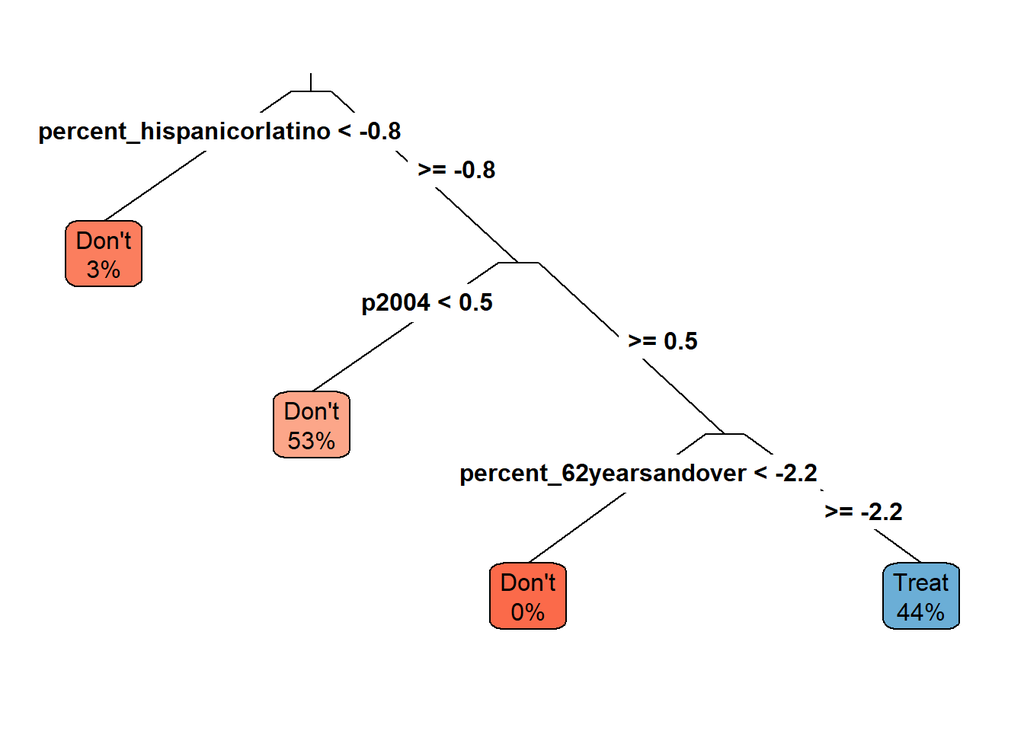

```r
rpart.plot(pihat, type = 3,
           fallen =FALSE,
           leaf.round=1,
           extra=100,
           branch=.1,
           box.palette="RdBu")
```

```r
#Compare to just using the tau.hat in a tree
pihat2 <- rpart(formula = str_c("Z2 ~ ", regressors), # Predict sign of treatment
                data = df_aug,
                weights = df_aug$lambda2,  # Larger effect --> Higher weight
                method = "class",
                control = rpart.control(maxdepth = 3, cp=.0001))

pihat2$cptable
```

```
           CP nsplit rel error    xerror       xstd
1 0.002537197      0 1.0000000 1.0000000 0.08692893
2 0.000100000      3 0.9923884 0.9978954 0.08688733
```

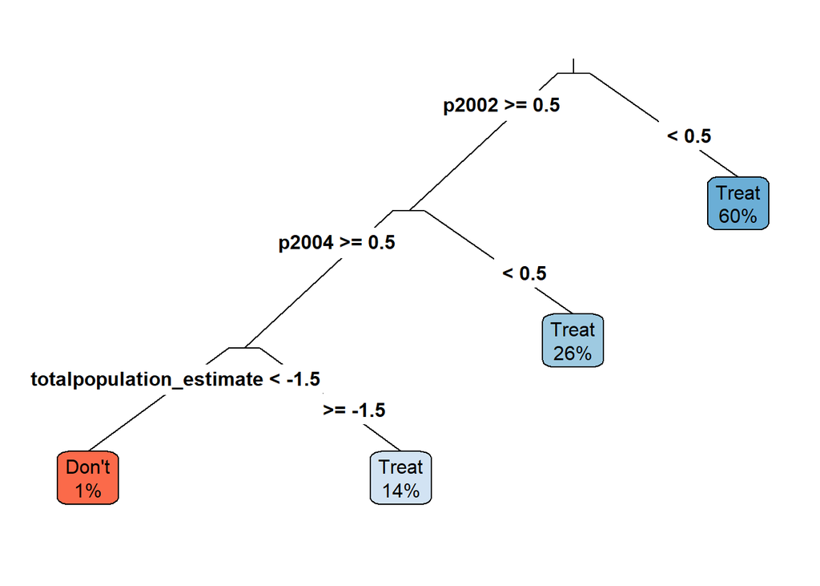

```r
rpart.plot(pihat2, type = 3,
           fallen =FALSE,
           leaf.round=1,
           extra=100,
           branch=.1,
           box.palette="RdBu")
```

```r
#Try a third approach, which is not restricted to be "simple," just based on the tau.hat

pihat3 <- as.factor(sign(df_aug$tau.hat - COST))
summary(pihat3)
```

```
   -1     1
12739  3260
```

Formally, for the group where $\pi(X_i)=1$,
$$E[Y_i(\hat\pi(X_i))-\frac{1}{2}(Y_i(1)+Y_i(0))\Big| \hat\pi(X_i)=1]=\frac{1}{2} E[(Y_i(1)-Y_i(0))]$$
While in the group where $\pi(X_i)=0$,
$$E[Y_i(\hat\pi(X_i))-\frac{1}{2}(Y_i(1)+Y_i(0))\Big| \hat\pi(X_i)=0]=-\frac{1}{2} E[(Y_i(1)-Y_i(0))]$$
Thus, overall,
$$E[Y_i(\hat\pi(X_i))-\frac{1}{2}(Y_i(1)+Y_i(0))]=\frac{1}{2} E[(Y_i(1)-Y_i(0))\Big|\hat\pi(X_i)=1]\cdot Pr(\hat\pi(X_i)=1)$$
$$-\frac{1}{2} E[(Y_i(1)-Y_i(0))\Big|\hat\pi(X_i)=0]\cdot Pr(\hat\pi(X_i)=0)$$

To estimate these treatment effects, we simply run a regression on indicator variables for being in the group assigned to treatment by $\hat\pi(\cdot)$, as well as interaction of that indicator with the dummy for being treated in the data. The coefficients on the interaction terms give us the sample average treatment effect in each group.

We do this both for our preferred approach, and for the approach where the $\Gamma_i$ weight are simply determined by the estimated treatment effects.

When evaluating the results below, recall that we imposed a treatment COST in the treatment assignment policy estimation. So a treatment effect of greater than COST is worthwhile to treat, while a treatment effect of less than COST should not be treated. We create a new outcome variable that incorporates the COST, the treatment effects need to be adjusted by COST to compare to treatment effects estimated elsewhere in the tutorial.

Also, note that the policy looks much better in the training data than in the test data. This is another example where honesty may be important: use sample splitting in some form.

```r
df_train$YminCost = df_train$Y - df_train$W*COST
df_test$YminCost = df_test$Y - df_test$W*COST

summary(lm(YminCost~W,data=df_train))
```

```
Call:
lm(formula = YminCost ~ W, data = df_train)

Residuals:
    Min      1Q  Median      3Q     Max
-0.3916 -0.3022 -0.3022  0.6978  0.6978

Coefficients:
             Estimate Std. Error t value Pr(>|t|)
(Intercept)  0.302188   0.004011  75.347   <2e-16 ***
W           -0.010617   0.009930  -1.069    0.285
---
Signif. codes:  0 '***' 0.001 '**' 0.01 '*' 0.05 '.' 0.1 ' ' 1

Residual standard error: 0.4641 on 15997 degrees of freedom
Multiple R-squared:  7.147e-05, Adjusted R-squared:  8.959e-06
F-statistic: 1.143 on 1 and 15997 DF,  p-value: 0.285
```

```r
summary(lm(YminCost~W,data=df_test))
```

```
Call:
lm(formula = YminCost ~ W, data = df_test)

Residuals:
    Min      1Q  Median      3Q     Max
-0.3800 -0.3062 -0.3062  0.6938  0.6938

Coefficients:
             Estimate Std. Error t value Pr(>|t|)
(Intercept)  0.306172   0.004041  75.766  < 2e-16 ***
W           -0.026121   0.009753  -2.678  0.00741 **
---
Signif. codes:  0 '***' 0.001 '**' 0.01 '*' 0.05 '.' 0.1 ' ' 1

Residual standard error: 0.4652 on 15999 degrees of freedom
Multiple R-squared:  0.0004481, Adjusted R-squared:  0.0003857
F-statistic: 7.173 on 1 and 15999 DF,  p-value: 0.007409
```

Above, we see the treatment effects overall in the training and test data. Next, we evaluate three policies on train and test data in sequence.

```r
policy_assign_train <- predict(pihat, newdata = df_train, type="class")
effects_policy_train <- lm(YminCost~policy_assign_train*W-1-W, data=df_train)
summary(effects_policy_train)
```

```
Call:
lm(formula = YminCost ~ policy_assign_train * W - 1 - W, data = df_train)

Residuals:
    Min      1Q  Median      3Q     Max
-0.4844 -0.3284 -0.2585  0.6328  0.7415

Coefficients:
                            Estimate Std. Error t value Pr(>|t|)
policy_assign_trainDon't    0.258492   0.005146  50.232   <2e-16 ***
policy_assign_trainTreat    0.367218   0.006278  58.497   <2e-16 ***
policy_assign_trainDon't:W -0.030095   0.012768  -2.357   0.0184 *
policy_assign_trainTreat:W  0.017172   0.015493   1.108   0.2677
---
Signif. codes:  0 '***' 0.001 '**' 0.01 '*' 0.05 '.' 0.1 ' ' 1

Residual standard error: 0.4605 on 15995 degrees of freedom
Multiple R-squared:  0.3063,    Adjusted R-squared:  0.3062
F-statistic:  1766 on 4 and 15995 DF,  p-value: < 2.2e-16
```

```r
summary(policy_assign_train)
```

```
Don't Treat
 9561  6438
```

```r
policy_assign_test <- predict(pihat, newdata = df_test, type="class")
effects_policy_test <- lm(YminCost~policy_assign_test*W-1-W, data=df_test)
summary(effects_policy_test)
```

```
Call:
lm(formula = YminCost ~ policy_assign_test * W - 1 - W, data = df_test)

Residuals:
    Min      1Q  Median      3Q     Max
-0.4667 -0.3200 -0.2576  0.6226  0.7424

Coefficients:
                           Estimate Std. Error t value Pr(>|t|)
policy_assign_testDon't    0.257614   0.005195  49.584  < 2e-16 ***
policy_assign_testTreat    0.377373   0.006291  59.983  < 2e-16 ***
policy_assign_testDon't:W -0.037639   0.012575  -2.993  0.00277 **
policy_assign_testTreat:W -0.010706   0.015121  -0.708  0.47896
---
Signif. codes:  0 '***' 0.001 '**' 0.01 '*' 0.05 '.' 0.1 ' ' 1

Residual standard error: 0.4612 on 15997 degrees of freedom
Multiple R-squared:  0.3085,    Adjusted R-squared:  0.3083
F-statistic:  1784 on 4 and 15997 DF,  p-value: < 2.2e-16
```

```r
summary(policy_assign_test)
```

```
Don't Treat
 9502  6499
```

```r
#Compare to the results based on a tree estimated using tau.hat-COST only

policy_assign2_train <- predict(pihat2, newdata = df_train, type="class")
effects_policy2_train <- lm(YminCost~policy_assign2_train*W-1-W, data=df_train)
summary(effects_policy2_train)
```

```
Call:
lm(formula = YminCost ~ policy_assign2_train * W - 1 - W, data = df_train)

Residuals:
    Min      1Q  Median      3Q     Max
-0.6757 -0.3011 -0.3011  0.6988  0.6988

Coefficients:
                             Estimate Std. Error t value Pr(>|t|)
policy_assign2_trainDon't    0.675676   0.076240   8.862  < 2e-16 ***
policy_assign2_trainTreat    0.301153   0.004013  75.037  < 2e-16 ***
policy_assign2_trainDon't:W -0.391060   0.149520  -2.615  0.00892 **
policy_assign2_trainTreat:W -0.009548   0.009946  -0.960  0.33709
---
Signif. codes:  0 '***' 0.001 '**' 0.01 '*' 0.05 '.' 0.1 ' ' 1

Residual standard error: 0.4638 on 15995 degrees of freedom
Multiple R-squared:  0.2965,    Adjusted R-squared:  0.2963
F-statistic:  1685 on 4 and 15995 DF,  p-value: < 2.2e-16
```

```r
summary(policy_assign2_train)
```

```
Don't Treat
   50 15949
```

```r
policy_assign2_test <- predict(pihat2, newdata = df_test, type="class")
effects_policy2_test <- lm(YminCost~policy_assign2_test*W-1-W, data=df_test)
summary(effects_policy2_test)
```

```
Call:
lm(formula = YminCost ~ policy_assign2_test * W - 1 - W, data = df_test)

Residuals:
    Min      1Q  Median      3Q     Max
-0.5714 -0.3056 -0.3056  0.6944  0.6944

Coefficients:
                            Estimate Std. Error t value Pr(>|t|)
policy_assign2_testDon't    0.514286   0.078623   6.541 6.29e-11 ***
policy_assign2_testTreat    0.305621   0.004046  75.544  < 2e-16 ***
policy_assign2_testDon't:W -0.042857   0.192585  -0.223  0.82390
policy_assign2_testTreat:W -0.026059   0.009764  -2.669  0.00762 **
---
Signif. codes:  0 '***' 0.001 '**' 0.01 '*' 0.05 '.' 0.1 ' ' 1

Residual standard error: 0.4651 on 15997 degrees of freedom
Multiple R-squared:  0.2966,    Adjusted R-squared:  0.2965
F-statistic:  1687 on 4 and 15997 DF,  p-value: < 2.2e-16
```

```r
summary(policy_assign2_test)
```

```
Don't Treat
   42 15959
```

```r
#Compare to the results based on a pointwise policy built on tau.hat-COST

policy_assign3_train <- pihat3
effects_policy3_train <- lm(YminCost~policy_assign3_train*W-1-W, data=df_train)
summary(effects_policy3_train)
```

```
Call:
lm(formula = YminCost ~ policy_assign3_train * W - 1 - W, data = df_train)

Residuals:
    Min      1Q  Median      3Q     Max
-0.3962 -0.2927 -0.2927  0.6610  0.7073

Coefficients:
                          Estimate Std. Error t value Pr(>|t|)
policy_assign3_train-1    0.292704   0.004494  65.128   <2e-16 ***
policy_assign3_train1     0.339051   0.008860  38.267   <2e-16 ***
policy_assign3_train-1:W -0.002273   0.011096  -0.205   0.8377
policy_assign3_train1:W  -0.042897   0.022184  -1.934   0.0532 .
---
Signif. codes:  0 '***' 0.001 '**' 0.01 '*' 0.05 '.' 0.1 ' ' 1

Residual standard error: 0.4638 on 15995 degrees of freedom
Multiple R-squared:  0.2964,    Adjusted R-squared:  0.2962
F-statistic:  1684 on 4 and 15995 DF,  p-value: < 2.2e-16
```

```r
summary(policy_assign3_train)
```

```
   -1     1
12739  3260
```

```r
policy_assign3_test <- as.factor(sign(as.numeric(cf_res$predictions) - COST)) #cf_res defined as predicted CATE on test set in previous section when CF is estimated
effects_policy3_test <- lm(YminCost~policy_assign3_test*W-1-W, data=df_test)
summary(effects_policy3_test)
```

```
Call:
lm(formula = YminCost ~ policy_assign3_test * W - 1 - W, data = df_test)

Residuals:
    Min      1Q  Median      3Q     Max
-0.4205 -0.2963 -0.2963  0.6526  0.7037

Coefficients:
                         Estimate Std. Error t value Pr(>|t|)
policy_assign3_test-1    0.296286   0.004496  65.901   <2e-16 ***
policy_assign3_test1     0.347368   0.009178  37.848   <2e-16 ***
policy_assign3_test-1:W -0.025600   0.010819  -2.366    0.018 *
policy_assign3_test1:W  -0.026826   0.022427  -1.196    0.232
---
Signif. codes:  0 '***' 0.001 '**' 0.01 '*' 0.05 '.' 0.1 ' ' 1

Residual standard error: 0.4648 on 15997 degrees of freedom
Multiple R-squared:  0.2976,    Adjusted R-squared:  0.2974
F-statistic:  1694 on 4 and 15997 DF,  p-value: < 2.2e-16
```

```r
summary(policy_assign3_test)
```

```
   -1     1
12920  3081
```